```r
library("tinytex")
```

## Data Pre Processing

Loading required packages

Reading the CSV file and Converting it into a DataFrame

```r
data = read.csv("C:\\Users\\anand\\Downloads\\stat_data.csv")
data_df = data.frame(data)
```

Data Pre Processing Check for any null values

```r
is.null(data_df)
```

```
## [1] FALSE
```

```r
summary(data_df)
```

```
##    Country               GDP             Population          Medal2008
##  Length:71          Min.   :    6.52   Min.   :3.537e+05   Min.   :  1.00
##  Class :character   1st Qu.:   51.52   1st Qu.:5.513e+06   1st Qu.:  2.00
##  Mode  :character   Median :  229.53   Median :1.673e+07   Median :  6.00
##                     Mean   :  903.25   Mean   :7.384e+07   Mean   : 13.11
##                     3rd Qu.:  704.37   3rd Qu.:4.958e+07   3rd Qu.: 13.50
##                     Max.   :15094.00   Max.   :1.347e+09   Max.   :110.00
##    Medal2012       Medal2016
##  Min.   :  1.0   Min.   :  1.00
##  1st Qu.:  3.0   1st Qu.:  3.00
##  Median :  6.0   Median :  7.00
##  Mean   : 13.3   Mean   : 13.44
##  3rd Qu.: 13.0   3rd Qu.: 15.00
##  Max.   :104.0   Max.   :121.00
```

Distributions of variables

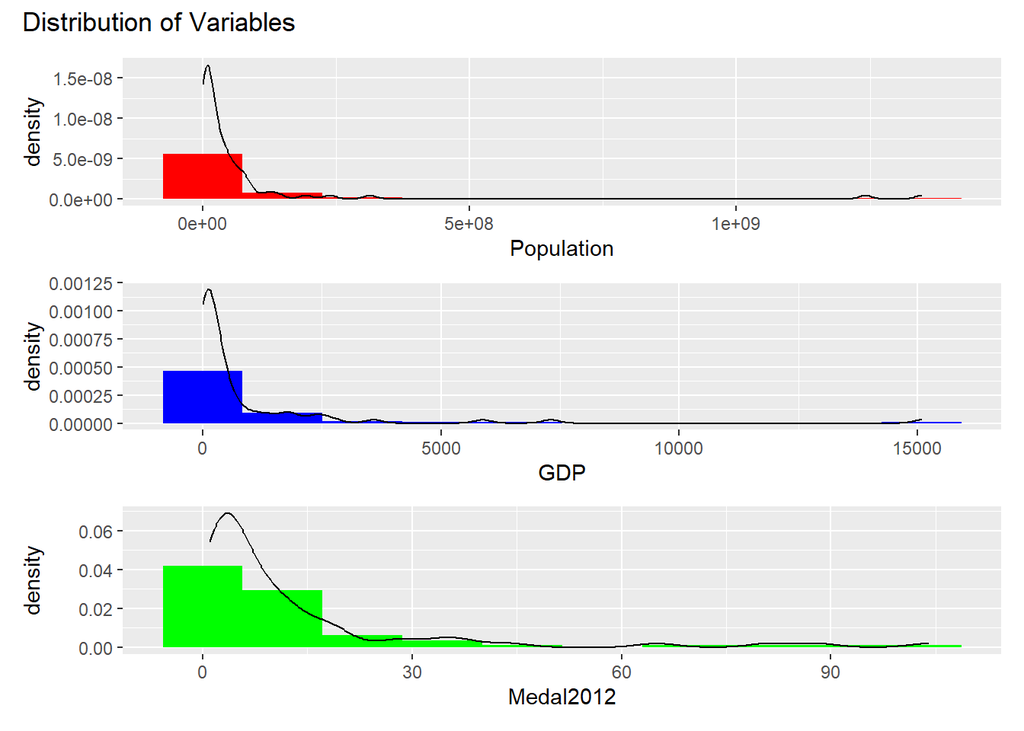

```r
p1 <- ggplot(
  data_df,
  aes(Population))+
  geom_histogram(aes(y = ..density..),bins = 10,fill = "Red")+ geom_density()

p2 <-ggplot(
  data_df,
  aes(GDP))+
  geom_histogram(aes(y = ..density..),bins = 10 ,fill = "Blue")+ geom_density()

p3 <-ggplot(
  data_df,
  aes(Medal2012))+
  geom_histogram(aes(y = ..density..),bins = 10,fill = "Green")+ geom_density()

library(patchwork)
p4 <- p1/p2+p3+plot_annotation(
  title = "Distribution of Variables"
)

p4
```

From the above distributions we can infer that data is positively skewed /right skewed distribution. which can impact our predictions and model performance to counter this we will apply transformations to our variables and we will see that in task 2.

### Task one model

```r
model = glm(Medal2012 ~ GDP+Population,data = data_df)
summary(model)
```

```
##
## Call:
## glm(formula = Medal2012 ~ GDP + Population, data = data_df)
##
## Deviance Residuals:
##     Min       1Q   Median       3Q      Max
## -20.568   -5.961   -2.462    3.932   60.121
##
## Coefficients:
##              Estimate Std. Error t value Pr(>|t|)
## (Intercept) 6.076e+00  1.500e+00   4.051 0.000133 ***
## GDP         7.564e-03  7.325e-04  10.326 1.45e-15 ***
## Population  5.247e-09  7.193e-09   0.729 0.468225
## ---
## Signif. codes:  0 '***' 0.001 '**' 0.01 '*' 0.05 '.' 0.1 ' ' 1
##
## (Dispersion parameter for gaussian family taken to be 132.1562)
##
##     Null deviance: 28402.8  on 70  degrees of freedom
## Residual deviance:  8986.6  on 68  degrees of freedom
## AIC: 553.19
##
## Number of Fisher Scoring iterations: 2
```

```r
prediction <- fitted(model)

data_df = mutate(data_df,Pred_2016_model_1 = prediction)
```

Plotting the Actual vs Predicted and The axes are transformed for improving clarity.

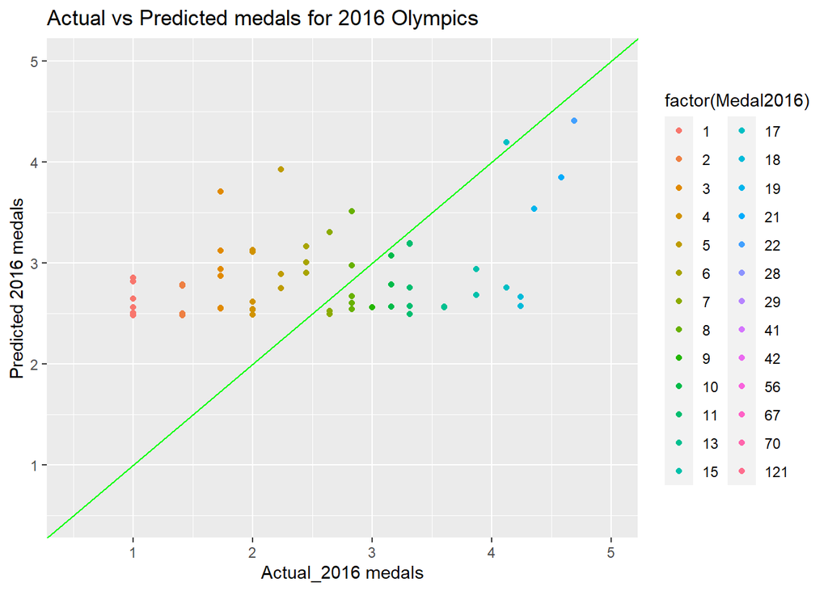

```r
ggplot(
  data_df,
  aes( x = sqrt(Medal2016),y = sqrt(Pred_2016_model_1),color = factor(Medal2016))
  )+geom_point()+geom_abline(color='Green')+
   ggtitle('Actual vs Predicted medals for 2016 Olympics') +
  xlab('Actual_2016 medals') +
  xlim(0.5,5)+
  ylim(0.5,5)+
  ylab('Predicted 2016 medals')
```

The plot of actual values versus predicted values shows how far the predictions are from the actual values. The abline in green represents the coincidence of the actual and predicted values

The ones above the line indicate that for a country, predicted value is higher than the actual value and the ones below the line indicate that the actual is higher than the predicted medal count.

## Evaluating model performance using Correlation , R-Squared and AIC Score

Creating a dataframe to store Evaluation metrics

```r
cor = cor(data_df$Pred_2016_model_1,data_df$Medal2016)
RMSE_model1 = round(RMSE(data_df$Pred_2016_model_1, data_df$Medal2016),5)


model_df <- data.frame("Model 1", round(cor^2, 5), round(AIC(model),5), round(BIC(model),5),RMSE_model1)
names(model_df) <- c('Model', 'R-Squared', 'AIC', 'BIC','RMSE')
model_df
```

```
##     Model R-Squared     AIC      BIC    RMSE
## 1 Model 1    0.7798 553.187 562.2377 9.11259
```

Log - Transforming the variables

```r
data_df = mutate(data_df,GDP_log = log(GDP))
data_df = mutate(data_df,population_log = log(Population))
```

The correlation is 0.62 if we do not transform the Medal2012.

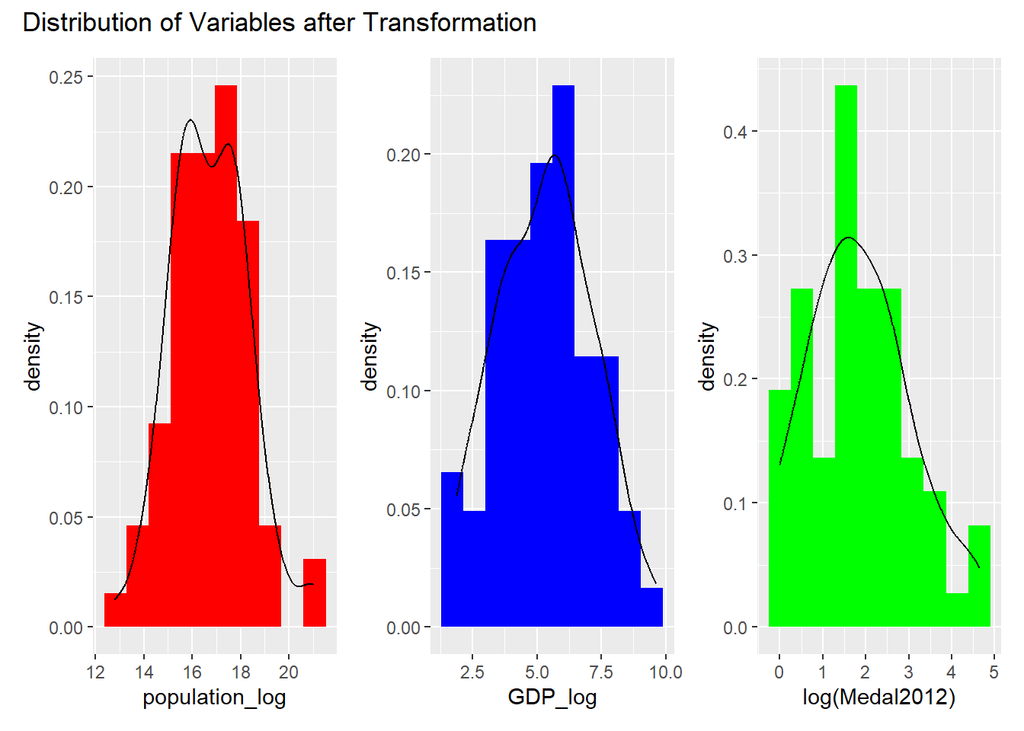

```r
p1 <- ggplot(
  data_df,
  aes(population_log))+
  geom_histogram(aes(y = ..density..),bins = 10,fill = "Red")+ geom_density()

p2 <-ggplot(
  data_df,
  aes(GDP_log))+
  geom_histogram(aes(y = ..density..),bins = 10 ,fill = "Blue")+ geom_density()

p3 <-ggplot(
  data_df,
  aes(log(Medal2012)))+
  geom_histogram(aes(y = ..density..),bins = 10,fill = "Green")+ geom_density()

library(patchwork)
p4 <- p1+p2+p3+plot_annotation(
  title = "Distribution of Variables after Transformation"
)

p4
```

From the above distributions we can infer that data is distributed symmetrically after log transformations.

Model for Task Two

After Experimenting with transformations we have come to the conclusion that log transforming only Population is far better than transforming both the inputs.When we consider R- squared values as a model selection metric then the former(log transforming only Population) R-squared score is **0.7856409** as compared to the latter R-squared score of **0.3906** and AIC score is lower for the former model(log transforming only Population).

```r
model_2 <- glm(data_df$Medal2012~ GDP+population_log, data = data_df)
summary(model_2)
```

```
##
## Call:
## glm(formula = data_df$Medal2012 ~ GDP + population_log, data = data_df)
##
## Deviance Residuals:
##     Min       1Q   Median       3Q      Max
## -20.477   -6.103   -1.660    2.692   57.715
##
## Coefficients:
##                  Estimate Std. Error t value Pr(>|t|)
## (Intercept)    -1.849e+01  1.677e+01  -1.103    0.274
## GDP             7.221e-03  7.544e-04   9.572 3.17e-14 ***
## population_log  1.510e+00  1.020e+00   1.480    0.143
## ---
## Signif. codes:  0 '***' 0.001 '**' 0.01 '*' 0.05 '.' 0.1 ' ' 1
##
## (Dispersion parameter for gaussian family taken to be 129.0332)
##
##     Null deviance: 28402.8  on 70  degrees of freedom
## Residual deviance:  8774.3  on 68  degrees of freedom
## AIC: 551.49
##
## Number of Fisher Scoring iterations: 2
```

Model Fitting

```r
prediction <- fitted(model_2)
data_df <- mutate(data_df,Pred_2016_model_2 = (prediction))
```

Plotting the Actual vs Predicted and The axes are transformed for improving clarity.

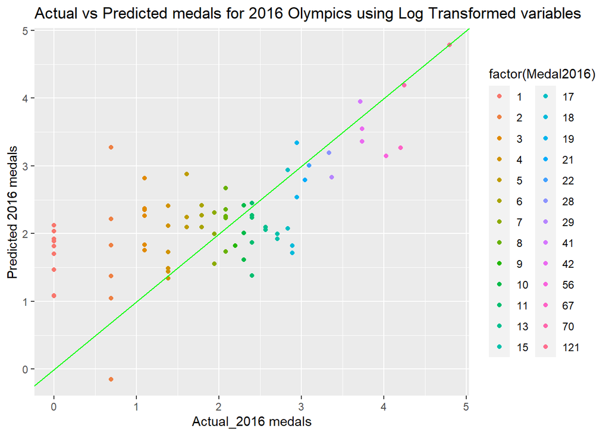

```r
ggplot(
  data_df,
  aes( x = log(Medal2016),y = log(Pred_2016_model_2),color = factor(Medal2016))
  )+geom_point()+geom_abline(color='Green')+
   ggtitle('Actual vs Predicted medals for 2016 Olympics using Log Transformed variables') +
  xlab('Actual_2016 medals') +

  ylab('Predicted 2016 medals')
```

The plot of actual values versus predicted values shows how far the predictions are from the actual values. The abline in green represents the coincidence of the actual and predicted values

The ones above the line indicate that for a country, predicted value is higher than the actual value and the ones below the line indicate that the actual is higher than the predicted medal count.

In this model the data points are mostly around the abline so we can expect that RMSE will be lower for this model.

## Evaluating model performance for log transformed model using R-Squared,AIC value,BIC value,RMSE.

```r
cor_2 = cor(data_df$Medal2016,data_df$Pred_2016_model_2)

RMSE_model2 = round(RMSE(data_df$Pred_2016_model_2, data_df$Medal2016),5)

model_df <- rbind(model_df, c("Model 2_Transformed", round(cor_2^2, 5), round(AIC(model_2),5), round(BIC(model_2),5),RMSE_model2))

model_df
```

```
##                 Model R-Squared       AIC       BIC    RMSE
## 1             Model 1    0.7798 553.18696 562.23768 9.11259
## 2 Model 2_Transformed   0.78564 551.48897 560.53969 8.98978
```

##Selecting best model:

Model_2 (Log transformed ) is better model than in task 1 model.The Reasons are:

AIC Scores: Akaike information criterion (AIC) is an estimator of prediction error.For model in Task 1 score is **553.187** where as in Model_2 (log transformed) the score is **551.489** .so we select the model with lowest prediction error and by Model_2 is the best.

BIC Scores: It is based on the likelihood function and it is closely related to the Akaike information criterion (AIC).For model in Task 1 score is **562.2377** where as in Model_2 (log transformed) the score is **560.5397**.so we select the model with lowest BIC score and by Model_2 is the best.

R-Squared value: it measures the goodness of fit of a model.The values of model in task 1 is **0.7798** and in Model_2 (log transformed) the score is **0.78564** .The **Higher** the value the better the performance of model

RMSE: This measures the average error performed by the model in predicting the outcome for an observation. The value of model_1 is **9.11259** and of model_2 transformed is **8.98978**.The **lower** the value the better the performance of model

So,based on the above statistical evidences we can say that model_2 (Log transformed) is the best model.

# Performing k means clustering

Installing required packages for performing Kmeans Clustering.

```r
library(broom)
#clustering
#install.packages("NbClust")
library(NbClust)
library(cluster)
require(factoextra)
```

Prepare the data for clustering - we will be doing scaling on the data.

Reasons:

1. By scaling the variables to have the same mean and standard deviation, we ensure that all variables contribute equally to the distance calculation. This improves the robustness and accuracy of the clustering algorithm.
2. Another Reasoning being k-means clustering algorithm is sensitive to the scale of the variables.

```r
scaled_data <- as.data.frame(scale(data_df[,c(2,9)]))
# In our data frame columns 8 and 9 are log transformed inputs
head(data_df[,c(1,2,9)],3)
```

```
##     Country    GDP population_log
## 1   Algeria 188.68       17.42913
## 2 Argentina 445.99       17.50731
## 3   Armenia  10.25       14.99984
```

To determine the optimal number of clusters we will be using the NbClust package in R.

we will be using **Elbow method** one of popular method determining the optimal number of clusters in a data set for k-means clustering. It is a simple and intuitive method that involves plotting the within-cluster sum of squares (WSS) against the number of clusters and looking for a “bend” or “elbow” in the plot.

WSS is measure of variance and it decreases as number of clusters increases but we should be vary of over fitting problem.so we need to strike balance variance and over fitting this can be achieved by using elbow method.

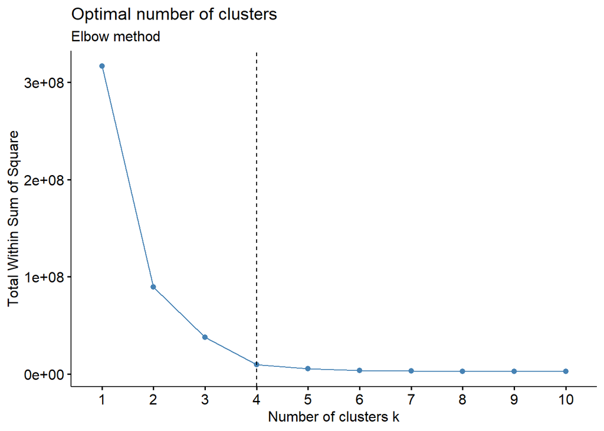

```r
fviz_nbclust(data_df[,c(2,9)], kmeans, method = "wss") +
  geom_vline(xintercept = 4, linetype = 2)+
  labs(subtitle = "Elbow method")
```

```r
kmeans_result <- kmeans(scaled_data, centers = 4)
```

```r
kmeans_result$size
```

```
## [1] 29 10 29  3
```

Adding the clusters to respective data points using mutate function so that later we can access them easily

```r
data_df <- mutate(data_df,cluster = kmeans_result$cluster )
head(data_df[,c(1,2,9,11)],5)
```

```
##      Country     GDP population_log cluster
## 1    Algeria  188.68       17.42913       3
## 2  Argentina  445.99       17.50731       3
## 3    Armenia   10.25       14.99984       2
## 4  Australia 1371.76       16.94580       3
## 5 Azerbaijan   63.40       16.02500       1
```

Visualizing clusters The axes are transformed for better clarity and understanding of clusters

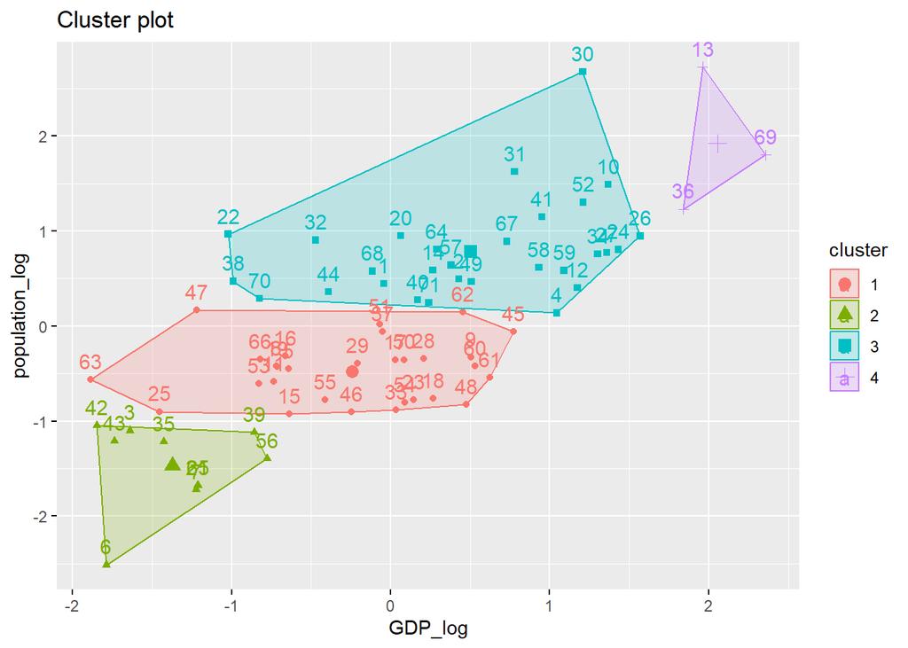

```r
fviz_cluster(kmeans_result, data = data_df[8:9])
```

Model Building

```r
cluster_assignments = kmeans_result$cluster


AIC_clust ={}
BIC_clust ={}

predictions <- rep(0, 71) # initialize predictions vector
for (i in 1:4) {
  # subset the data for the current cluster

  cluster <- data_df %>% filter(cluster == i)

  # train a linear regression model on the subset of data
  model_cluster <- glm(Medal2012 ~ GDP+ Population,data = cluster )

  # make predictions on the subset of data and store in the predictions vector
  predictions[cluster_assignments == i] <- fitted(model_cluster)

  cat("Evalaution metrics for cluster :",i,"\n")
  cat("\n","AIC Score", AIC(model_cluster), "\n","\n"
    ,"BIC Score:", BIC(model_cluster), "\n","\n"
    )
    cat("___________________________________","\n","\n")

    AIC_clust <- append(AIC_clust,AIC(model_cluster))
    BIC_clust <- append(BIC_clust,BIC(model_cluster))



}
```

```
## Evalaution metrics for cluster : 1
##
##  AIC Score 182.3289
##
##  BIC Score: 187.798
##
## ___________________________________
##
## Evalaution metrics for cluster : 2
##
##  AIC Score 56.98323
##
##  BIC Score: 58.19357
##
## ___________________________________
##
## Evalaution metrics for cluster : 3
##
##  AIC Score 241.5675
##
##  BIC Score: 247.0367
##
## ___________________________________
##
## Evalaution metrics for cluster : 4
##
##  AIC Score -174.5549
##
##  BIC Score: -178.1604
##
## ___________________________________
##
```

Plotting the Actual vs Predicted and The axes are transformed for improving clarity.

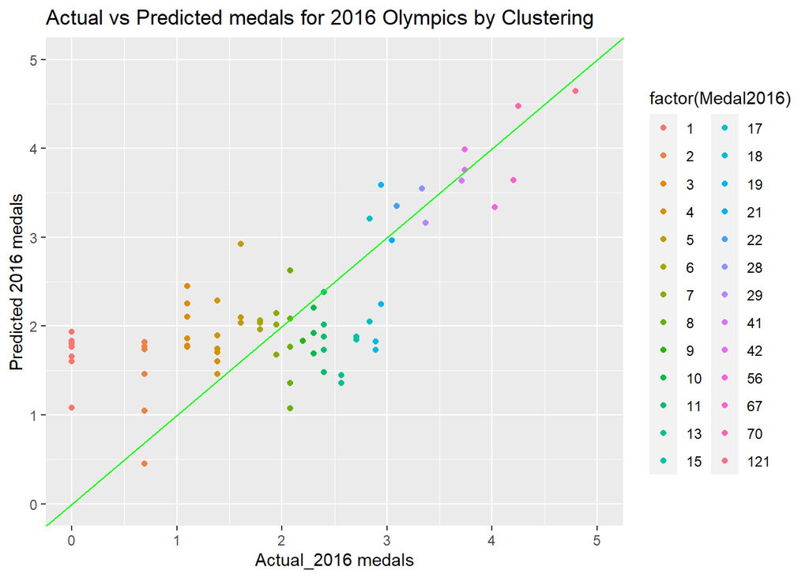

```r
ggplot(
  data_df,
  aes( x = log(Medal2016),y = log(predictions),color = factor(Medal2016))
  )+geom_point()+geom_abline(color='Green')+
   ggtitle('Actual vs Predicted medals for 2016 Olympics by Clustering') +
  xlab('Actual_2016 medals') +
  xlim(0,5)+
  ylim(0,5)+
  ylab('Predicted 2016 medals')
```

The plot of actual values versus predicted values shows how far the predictions are from the actual values.

The abline in green represents the coincidence of the actual and predicted values

The ones above the line indicate that for a country, predicted value is higher than the actual value and the ones below the line indicate that the actual is higher than the predicted medal count.

In this model the data points are around the abline so we can expect that RMSE will be lowest out of the 3 models and R Squared will be highest of all.

## Evaluating model performances using R-Squared,AIC value,BIC value,RMSE.

```r
data_df = mutate(data_df,Pred_2016_model_cluster = predictions)

c1 = cor(data_df$Pred_2016_model_cluster,data_df$Medal2016)

RMSE_model3 = round(RMSE(data_df$Pred_2016_model_cluster, data_df$Medal2016),5)

model_df <- rbind(model_df, c("Model 3_Kmeans", round(c1^2, 5), round(AIC(model_cluster),5), round(BIC(model_cluster),5),RMSE_model3))

model_df
```

```
##                 Model R-Squared        AIC        BIC    RMSE
## 1             Model 1    0.7798  553.18696  562.23768 9.11259
## 2 Model 2_Transformed   0.78564  551.48897  560.53969 8.98978
## 3      Model 3_Kmeans   0.83054 -174.55486 -178.16041 7.97857
```

Benefits of This approach :

Relatively simple to implement.

This approach can capture nonlinear relationships between the inputs and outputs by modeling each cluster with a linear regression model.

This can provide insights into the structure of the data by identifying groups of inputs that are related to similar outputs.

We can get performance metrics of each and every cluster so that we can finetune the parameters to improve the model.

## Model Selection

Model selection is done by considering the following metrics 1.Cross validation 2. RMSE 3. AIC scores 4. BIC scores 5. R-Squared Values

Cross validation:

It involves splitting the available data into a training set and a validation set, where the training set is used to train the model and the validation set is used to test its performance.

Splitting the data into Train and Test.Here we using 50 data points for training and 21 for testing i.e., 70% train and 30% testing

```r
train_indices <- sample(1:nrow(data_df), size = 50, replace = FALSE)
train_data <- data_df[train_indices, ]
test_data <- data_df[-train_indices, ]
```

We will be using the k-fold cross-validation.This involves splitting the data into 5(our value of k=5) equally sized folds, using 4 folds for training and the remaining fold for validation. This process is repeated 5 times, with each fold being used for validation once. The performance metrics are then averaged across all the runs.

we will be calculating the RMSE value.

To do so we will be using the purrr and modelr package in R

get_pred is a function that takes the models and test data and returns the predictions.

```r
#install.packages("purrr")
library(purrr)
library(modelr)
```

```r
cv  <- crossv_kfold(data_df, k = 5)

model_1  <- map(cv$train, ~glm(Medal2012~ GDP+Population, data = .))
model_2_transformed  <- map(cv$train, ~glm(Medal2012~ GDP+population_log, data = .))

get_pred  <- function(model, test_data){
  data  <- as.data.frame(test_data)
  pred  <- add_predictions(data, model)
  return(pred)
}

pred_1  <- map2_df(model_1, cv$test, get_pred, .id = "Run")
pred_2  <- map2_df(model_2_transformed, cv$test, get_pred, .id = "Run")

rmse_model1 <- RMSE(pred_1$Medal2016,pred_1$pred)
rmse_model2 <- RMSE(pred_2$Medal2016,pred_2$pred)
```

Performing cross validation on clusters

Perform on cross validation on each cluster with 70% train and 30% test data.

```r
kmeans_result$size
```

```
## [1] 29 10 29  3
```

```r
cluster_1 <- data_df %>% filter(cluster == 1)
cluster_2 <- data_df %>% filter(cluster == 2)
cluster_3 <- data_df %>% filter(cluster == 3)
cluster_4 <- data_df %>% filter(cluster == 4)
```

```r
train_indices <- sample(1:nrow(cluster_1), size = 20, replace = FALSE)
train_data_c1 <- cluster_1[train_indices, ]
test_data_c1 <- cluster_1[-train_indices, ]

train_indices <- sample(1:nrow(cluster_2), size = 7, replace = FALSE)
train_data_c2 <- cluster_2[train_indices, ]
test_data_c2 <- cluster_2[-train_indices, ]

train_indices <- sample(1:nrow(cluster_3), size = 20, replace = FALSE)
train_data_c3 <- cluster_3[train_indices, ]
test_data_c3 <- cluster_3[-train_indices, ]
```

Now we will perform k fold validation and calculate the mean of RMSE

```r
cv_1  <- crossv_kfold(cluster_1, k = 5)
cv_2  <- crossv_kfold(cluster_2, k = 5)
cv_3  <- crossv_kfold(cluster_3, k = 5)



model_c1  <- map(cv_1$train, ~glm(Medal2012~ GDP+Population, data = .))
model_c2  <- map(cv_2$train, ~glm(Medal2012~ GDP+Population, data = .))
model_c3  <- map(cv_3$train, ~glm(Medal2012~ GDP+Population, data = .))


get_pred  <- function(model, test_data){
  data  <- as.data.frame(test_data)
  pred  <- add_predictions(data, model)
  return(pred)
}

pred_c1  <- map2_df(model_c1, cv_1$test, get_pred, .id = "Run")
pred_c2  <- map2_df(model_c2, cv_2$test, get_pred, .id = "Run")
pred_c3  <- map2_df(model_c3, cv_3$test, get_pred, .id = "Run")


rmse_modelc1 <- RMSE(pred_c1$Medal2016,pred_c1$pred)
rmse_modelc2 <- RMSE(pred_c2$Medal2016,pred_c2$pred)
rmse_modelc3 <- RMSE(pred_c3$Medal2016,pred_c3$pred)

rmse_model3 <- sum(rmse_modelc1+rmse_modelc2+rmse_modelc3)/3
model_df$Cross_validation_RMSE <- c(rmse_model1,rmse_model2,rmse_model3)
```

Now selecting the Best model

```r
model_df[c(1,5,2,6)]
```

```
##                 Model    RMSE R-Squared Cross_validation_RMSE
## 1             Model 1 9.11259    0.7798             11.040453
## 2 Model 2_Transformed 8.98978   0.78564              9.616867
## 3      Model 3_Kmeans 7.97857   0.83054              9.757641
```

Model 3_Kmeans Findings:

The K-means algorithm allows us to partition the data into clusters and create linear regression models for each cluster, which can capture the unique relationships within each cluster. This approach can be particularly beneficial when dealing with complex data that may have non-linear relationships and/or interactions between the variables.

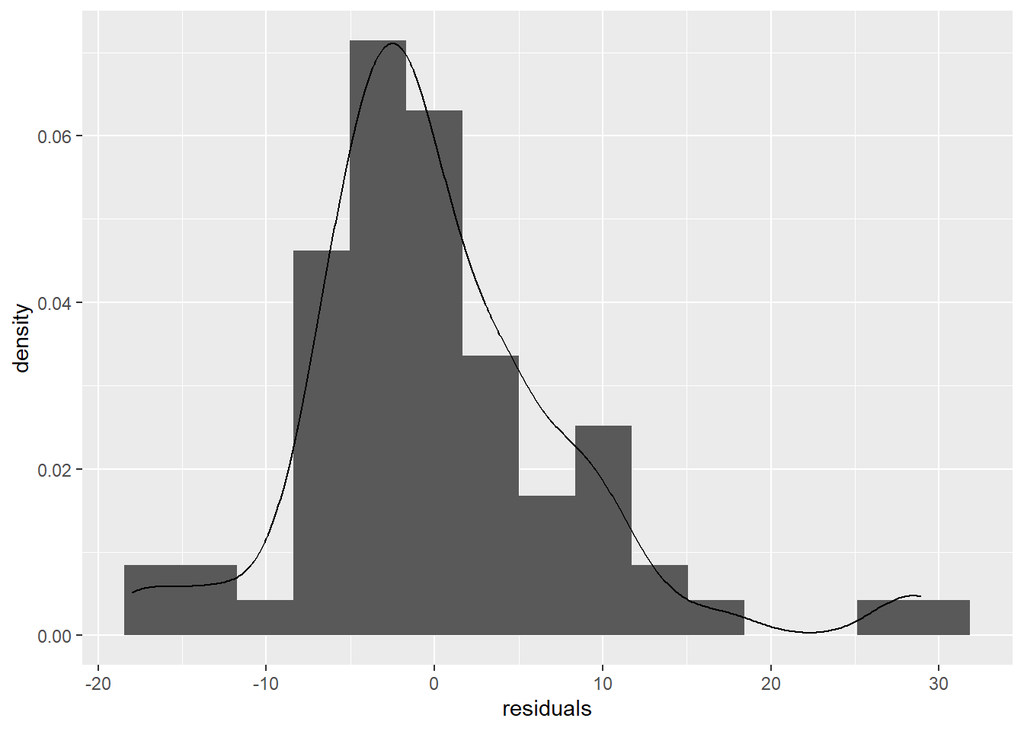

```r
residuals <- (data_df$Medal2016) - (data_df$Pred_2016_model_cluster)

ggplot(data_df, aes(x = residuals)) +
  geom_histogram(aes(y = ..density..),bins = 15)+geom_density()
```